# Global Temperature Analysis 1881 - 2012

Em Beauchamp and Martha Miller

The average global temperature from January 1881 through December 2012 is 57.1721023. According to the [national climate data center](https://www.ncdc.noaa.gov/sotc/global/201213), in 2012 the average global temperature was 58.03 and in 1880 the average global temperature was 56.5, so this number seems reasonable.

## Global Summer Temperatures 1881 - 2012 (Deg.F)

[output not shown]

The hottest years for June, July, and August were 1999, 2012, and 2012 respectively.The coldest were 1910, 1913, and 1913. It appears that the higher temperatures are generally occurring in more recent years.  
More evidence of this warming trend can be seen in the next section.

## Average Temperatures By Month

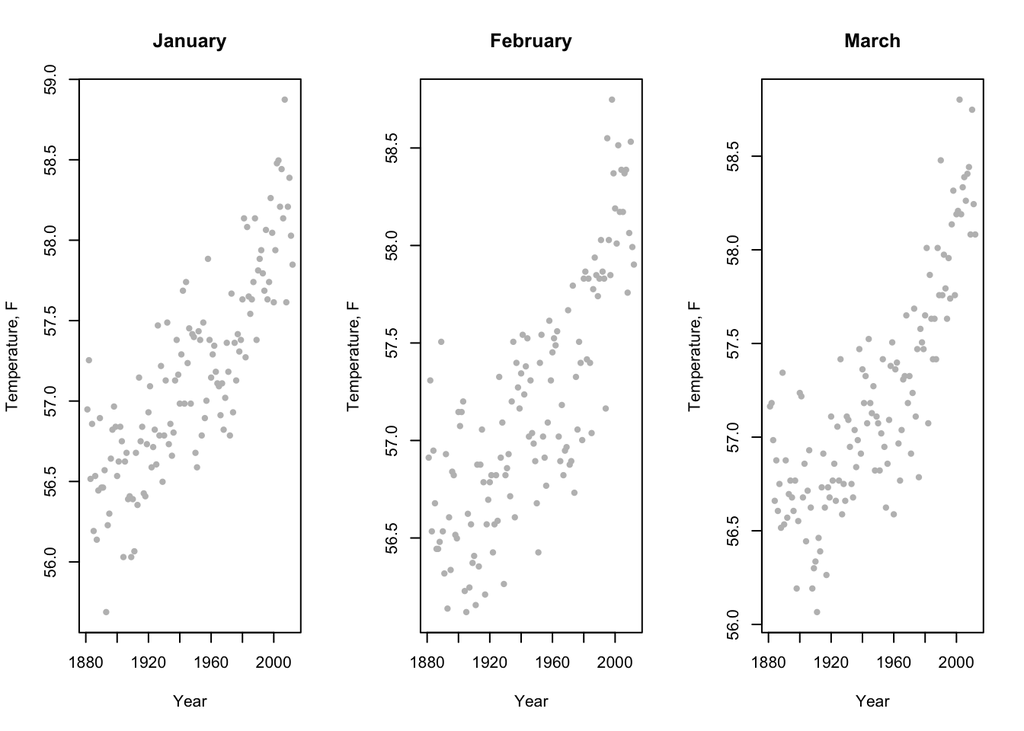

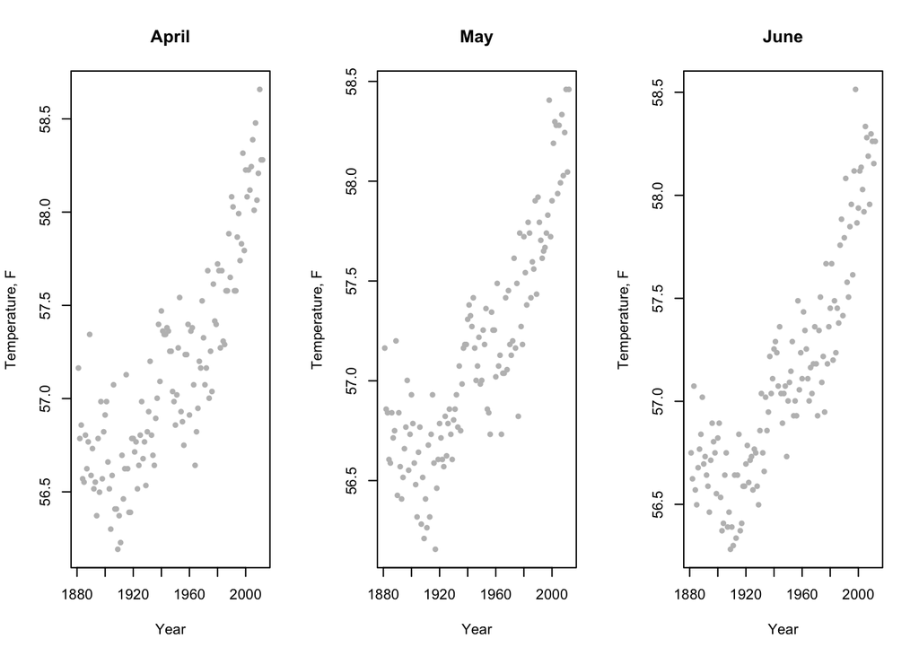

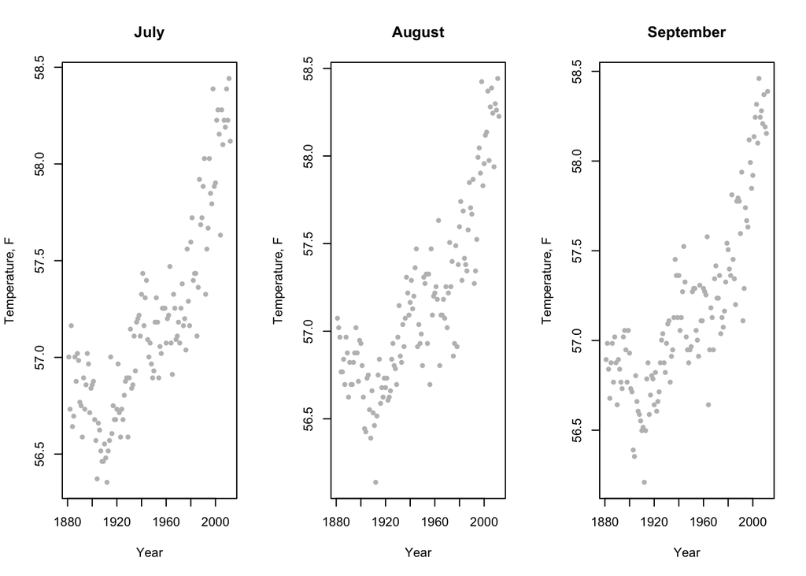

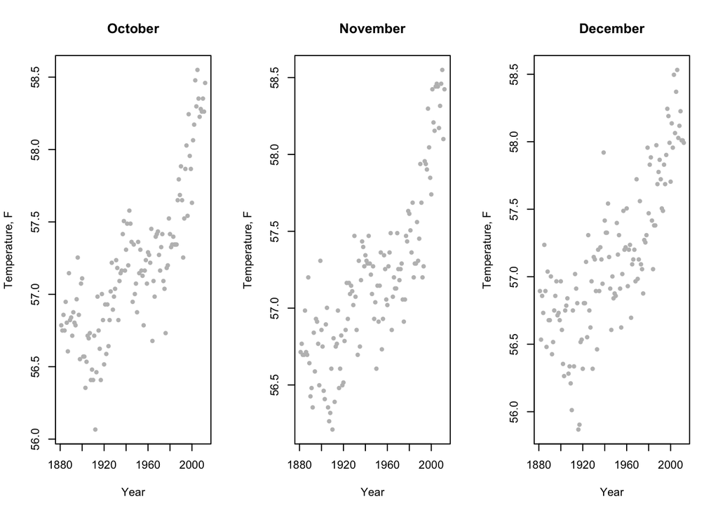

As seen in the plots, every month shows temperature increasing with year. Regardless of season, over the years temperature has increased.

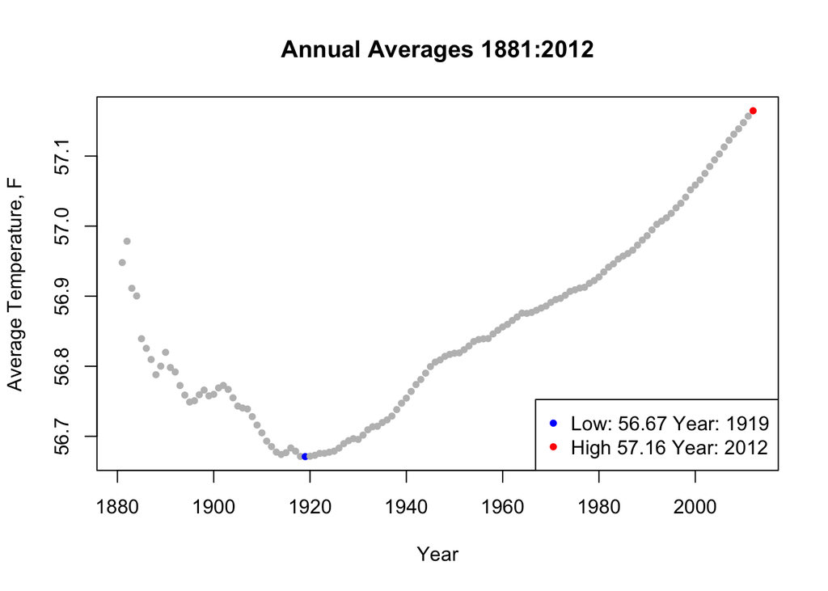

From 1881 to 1919 the annual average temperature was generally decreasing. In 1919 it hit the lowest annual average temperature so far of 56.67. After that it has been steadily increasing until 2012 when it hits the highest temperature so far, 57.16.

## Average Monthly Temperatures By Decades

Over 100 years ago, temperatures were relatively stable.

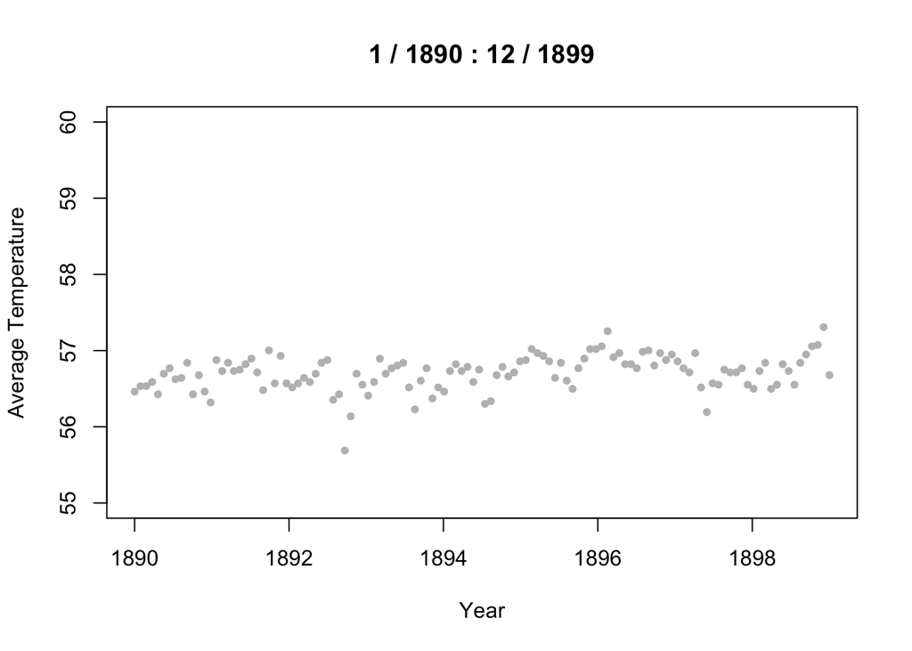

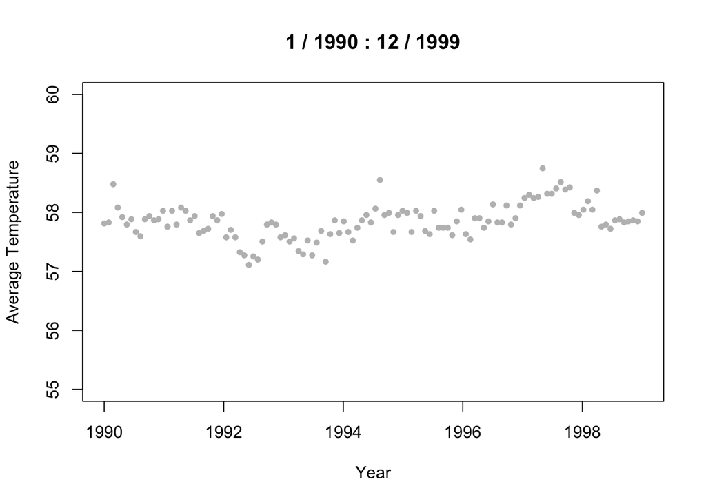

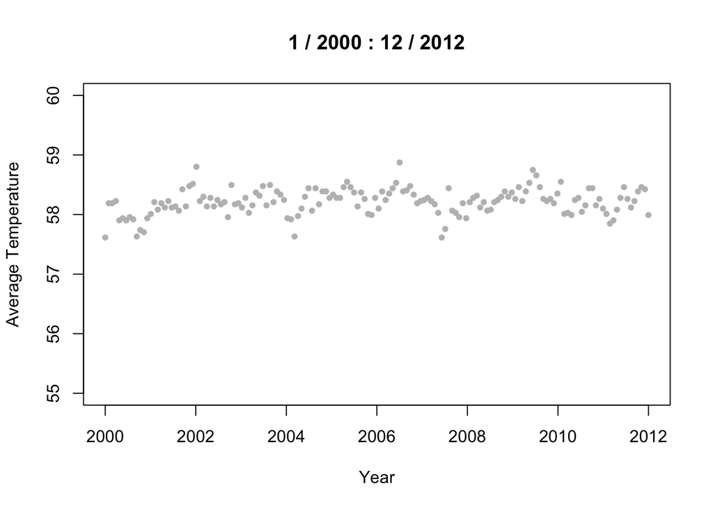

Increasing global temperatures can be seen clearly below. From 1881 to 1926 temperatures were relatively stable. From 1926 on, an temperature increase trend can be seen. This trend becomes stronger as time moves closer to the current.

## History of Average Monthly Temperatures : Three Eras

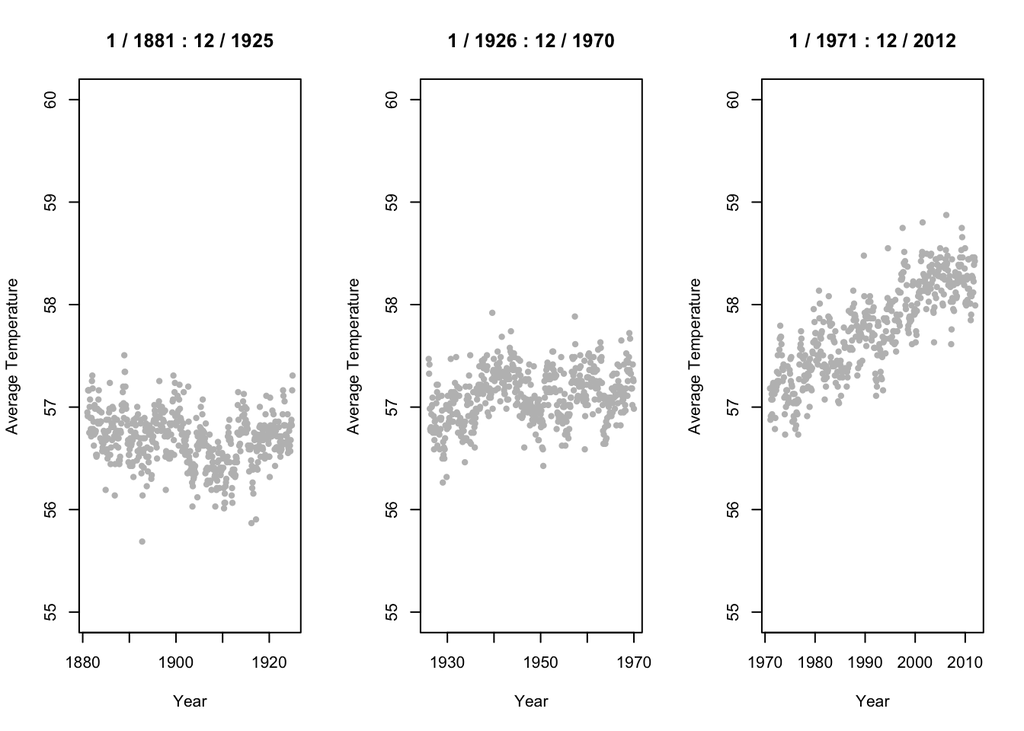